# Analysis of Geography-Based Happiness Patterns

Next, I wanted to look at the global happiness scores by their geographical factors, categorizing countries into coastal, landlocked, and climate zones. As nature is one of the factors that people find awe and interest, I thought nature could be a factor determining people’s happiness. Also, people living in extreme conditions would have difficulties living compared to those living in other moderate climates; in Korea, there are alerts when the weather gets too hot, cautioning people not to get irritated. Thus I thought climates, especially places that do not have favorable conditions for living, would influence peoples’ overall feelings. Patterns of happiness distribution and the role of geographic and climatic factors were analyzed.

```r
# Load libraries
library(tidyverse)
library(sf)
library(spdep)
library(viridis)
library(readxl)
library(rnaturalearth)
library(rnaturalearthdata)
library(corrplot)
```

```r
# Load spatial and happiness datasets
world_sf <- rnaturalearth::ne_countries(scale = "medium", returnclass = "sf")
happiness_data <- read_excel("../data/WHR20_DataForTable2.1.xls")
```

```r
# Select relevant columns
happiness_data <- happiness_data %>%
  select(
    `year`, `Country name`, `Life Ladder`, `Log GDP per capita`, `Social support`, `Freedom to make life choices`, `Healthy life expectancy at birth`,
    `Generosity`, `Perceptions of corruption`, `Democratic Quality`, `Delivery Quality`, `GINI index (World Bank estimate), average 2000-2017, unbalanced panel`,
    `Confidence in national government`, `gini of household income reported in Gallup, by wp5-year`
  )

happiness_data <- happiness_data %>%
  rename(`gini of income` = `gini of household income reported in Gallup, by wp5-year`)
```

```r
# Ensure the Life Ladder column is numeric
happiness_data <- happiness_data %>%
  mutate(`Life Ladder` = as.numeric(`Life Ladder`))
```

```r
key_variables <- c(
  "Life Ladder", "Log GDP per capita", "Delivery Quality",
  "Perceptions of corruption", "gini of income"
)
```

```r
# Merge spatial and happiness data
merged_sf <- left_join(world_sf, happiness_data, by = c("name" = "Country name"))
merged_sf <- merged_sf[!is.na(merged_sf$`Life Ladder`), ] # Remove rows with missing happiness scores
```

```r
merged_sf <- st_transform(merged_sf, crs = 3857)
world_sf <- st_transform(world_sf, crs = 3857)
```

### Coastal vs. Landlocked Countries

```r
# Load coastline data
coastline <- ne_download(scale = "medium", type = "coastline", category = "physical", returnclass = "sf")
# Combine coastlines into a single geometry
coastline_union <- st_union(coastline)
```

```r
# Ensure merged_sf and coastline_union have the same CRS
if (st_crs(merged_sf) != st_crs(coastline_union)) {
  coastline_union <- st_transform(coastline_union, st_crs(merged_sf))
}
```

```r
# Categorize countries as coastal or landlocked
merged_sf$coastal <- ifelse(
  lengths(st_is_within_distance(merged_sf$geometry, coastline_union, dist = 5 * 1000)) > 0,
  "Coastal",
  "Landlocked"
)
```

```r
# Compute summary statistics
coastal_stats <- merged_sf %>%
  group_by(coastal) %>%
  summarize(avg_happiness = mean(`Life Ladder`, na.rm = TRUE))

print(coastal_stats)
```

```
Simple feature collection with 2 features and 2 fields
Geometry type: MULTIPOLYGON
Dimension:     XY
Bounding box:  xmin: -20037510 ymin: -7536886 xmax: 20037510 ymax: 17928860
Projected CRS: WGS 84 / Pseudo-Mercator
# A tibble: 2 × 3
  coastal    avg_happiness                                              geometry
  <chr>              <dbl>                                    <MULTIPOLYGON [m]>
1 Coastal             5.61 (((-19616810 -5516741, -19616119 -5507870, -19617756…
2 Landlocked          4.95 (((-6456041 -2343584, -6454199 -2351065, -6452356 -2…
```

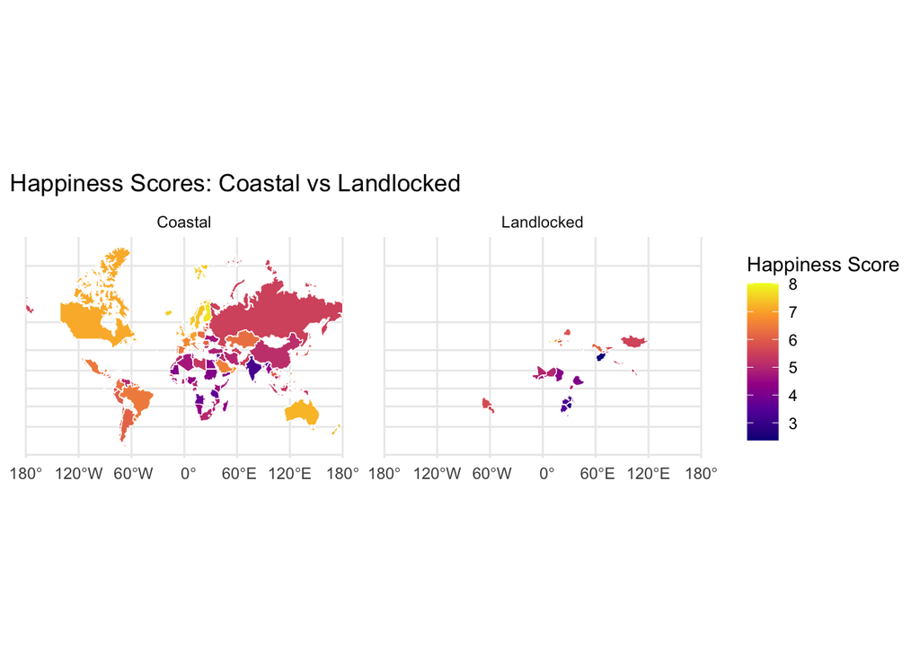

```r
# Visualize happiness scores for coastal vs. landlocked
ggplot(merged_sf) +
  geom_sf(aes(fill = `Life Ladder`), color = "white") +
  facet_wrap(~coastal) +
  scale_fill_viridis_c(option = "C") +
  theme_minimal() +
  labs(title = "Happiness Scores: Coastal vs Landlocked", fill = "Happiness Score")
```

Countries were classified as coastal or landlocked by assessing proximity to coastlines. A comparison of average happiness scores revealed that coastal countries tend to be happier (avg_happiness = 5.61) than landlocked countries (avg_happiness = 4.95). Choropleth maps visualized this distinction, highlighting higher happiness scores along coastlines.

```r
table(merged_sf$coastal)
```

```
   Coastal Landlocked
      1313        387
```

```r
# Subset coastal and landlocked countries
coastal_countries <- merged_sf[merged_sf$coastal == "Coastal", ]
landlocked_countries <- merged_sf[merged_sf$coastal == "Landlocked", ]

# Create spatial weights for coastal countries
coastal_coords <- st_coordinates(st_centroid(coastal_countries))
coastal_knn <- spdep::knearneigh(coastal_coords, k = 5)
coastal_listw <- spdep::nb2listw(spdep::knn2nb(coastal_knn), style = "W")

# Moran's I for coastal countries
coastal_moran <- spdep::moran.test(coastal_countries$`Life Ladder`, coastal_listw)
print(coastal_moran)
```

```
    Moran I test under randomisation

data:  coastal_countries$`Life Ladder`
weights: coastal_listw

Moran I statistic standard deviate = 59.681, p-value < 2.2e-16
alternative hypothesis: greater
sample estimates:
Moran I statistic       Expectation          Variance
     0.8947287248     -0.0007621951      0.0002251377
```

```r
# Create spatial weights for landlocked countries
landlocked_coords <- st_coordinates(st_centroid(landlocked_countries))
landlocked_knn <- spdep::knearneigh(landlocked_coords, k = 5)
landlocked_listw <- spdep::nb2listw(spdep::knn2nb(landlocked_knn), style = "W")

# Moran's I for landlocked countries
landlocked_moran <- spdep::moran.test(landlocked_countries$`Life Ladder`, landlocked_listw)
print(landlocked_moran)
```

```
    Moran I test under randomisation

data:  landlocked_countries$`Life Ladder`
weights: landlocked_listw

Moran I statistic standard deviate = 27.586, p-value < 2.2e-16
alternative hypothesis: greater
sample estimates:
Moran I statistic       Expectation          Variance
      0.750651349      -0.002590674       0.000745582
```

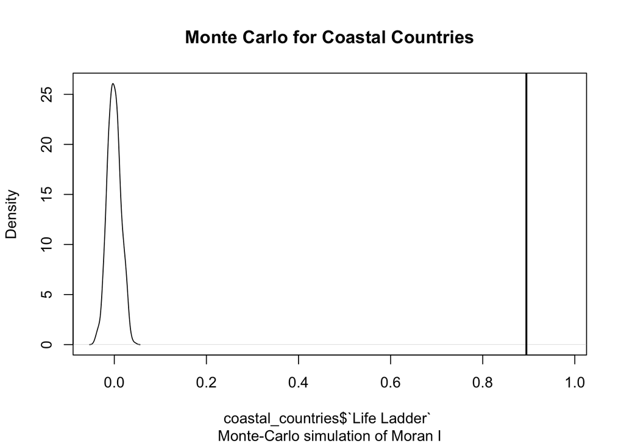

```r
# Monte Carlo simulation for coastal countries
coastal_mc <- spdep::moran.mc(coastal_countries$`Life Ladder`, coastal_listw, nsim = 999)
plot(coastal_mc, main = "Monte Carlo for Coastal Countries")
```

```r
print(coastal_mc)
```

```
    Monte-Carlo simulation of Moran I

data:  coastal_countries$`Life Ladder`
weights: coastal_listw
number of simulations + 1: 1000

statistic = 0.89473, observed rank = 1000, p-value = 0.001
alternative hypothesis: greater
```

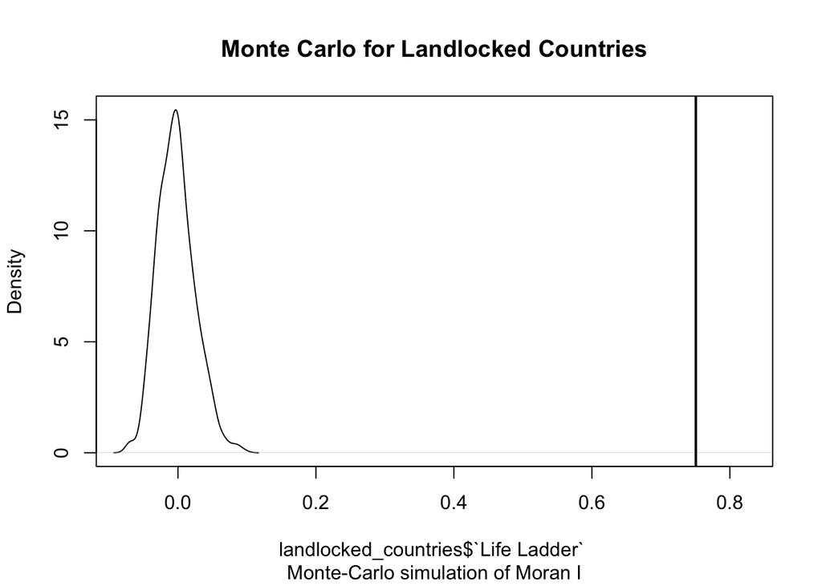

```r
# Monte Carlo simulation for landlocked countries
landlocked_mc <- spdep::moran.mc(landlocked_countries$`Life Ladder`, landlocked_listw, nsim = 999)
plot(landlocked_mc, main = "Monte Carlo for Landlocked Countries")
```

```r
print(landlocked_mc)
```

```
    Monte-Carlo simulation of Moran I

data:  landlocked_countries$`Life Ladder`
weights: landlocked_listw
number of simulations + 1: 1000

statistic = 0.75065, observed rank = 1000, p-value = 0.001
alternative hypothesis: greater
```

```r
# Convert political_freedom_category to numeric
merged_sf$coastal_numeric <- as.numeric(as.factor(merged_sf$coastal))

# Compute Moran's I for Political Freedom
coastal_countries_nb <- spdep::poly2nb(merged_sf, queen = TRUE)

# Allow empty neighbor sets
coastal_countries_listw <- spdep::nb2listw(coastal_countries_nb, style = "W", zero.policy = TRUE)

# Compute Moran's I for the numeric version of political freedom
coastal_countries_moran <- spdep::moran.test(merged_sf$coastal_numeric, coastal_countries_listw, zero.policy = TRUE)

# Print the Moran's I result
print(coastal_countries_moran)
```

```
    Moran I test under randomisation

data:  merged_sf$coastal_numeric
weights: coastal_countries_listw
n reduced by no-neighbour observations

Moran I statistic standard deviate = 53.815, p-value < 2.2e-16
alternative hypothesis: greater
sample estimates:
Moran I statistic       Expectation          Variance
     3.110764e-01     -5.892752e-04      3.354108e-05
```

### Climate Zones and Happiness

Countries were further categorized into climate zones (Tropical, Subtropical, Temperate, and Polar) based on latitude. Average happiness scores varied across these zones:

Polar: 7.09 (highest) Temperate: 5.92 Subtropical: 5.57 Tropical: 4.93 (lowest)

```r
merged_sf <- st_transform(merged_sf, crs = 4326)
merged_sf$latitude <- st_coordinates(st_centroid(merged_sf))[, 2]
```

```r
summary(merged_sf$latitude)
```

```
   Min. 1st Qu.  Median    Mean 3rd Qu.    Max.
-41.702   7.948  24.087  22.712  42.716  66.360
```

```r
# Categorize countries into climate zones
merged_sf$climate_zone <- case_when(
  merged_sf$latitude >= -23.5 & merged_sf$latitude <= 23.5 ~ "Tropical",
  merged_sf$latitude > 23.5 & merged_sf$latitude <= 40 ~ "Sub Tropical",
  merged_sf$latitude < -23.5 & merged_sf$latitude >= -40 ~ "Sub Tropical",
  merged_sf$latitude > 40 & merged_sf$latitude <= 60 ~ "Temperate",
  merged_sf$latitude < -40 & merged_sf$latitude >= -60 ~ "Temperate",
  merged_sf$latitude > 60 | merged_sf$latitude < -60 ~ "Polar",
  TRUE ~ NA_character_ # Assign NA if no condition matches
)

# Compute average happiness by climate zone
climate_stats <- merged_sf %>%
  group_by(climate_zone) %>%
  summarize(avg_happiness = mean(`Life Ladder`, na.rm = TRUE))

print(climate_stats)
```

```
Simple feature collection with 4 features and 2 fields
Geometry type: MULTIPOLYGON
Dimension:     XY
Bounding box:  xmin: -180 ymin: -55.8917 xmax: 180 ymax: 83.11611
Geodetic CRS:  WGS 84
# A tibble: 4 × 3
  climate_zone avg_happiness                                            geometry
  <chr>                <dbl>                                  <MULTIPOLYGON [°]>
1 Polar                 7.09 (((21.97979 60.35522, 21.90781 60.39316, 21.95029 …
2 Sub Tropical          5.57 (((53.05518 39.03794, 53.09219 39.09409, 53.05332 …
3 Temperate             5.92 (((21.03174 55.35049, 21.10391 55.48774, 21.11572 …
4 Tropical              4.93 (((-12.50063 7.535107, -12.5125 7.582422, -12.5441…
```

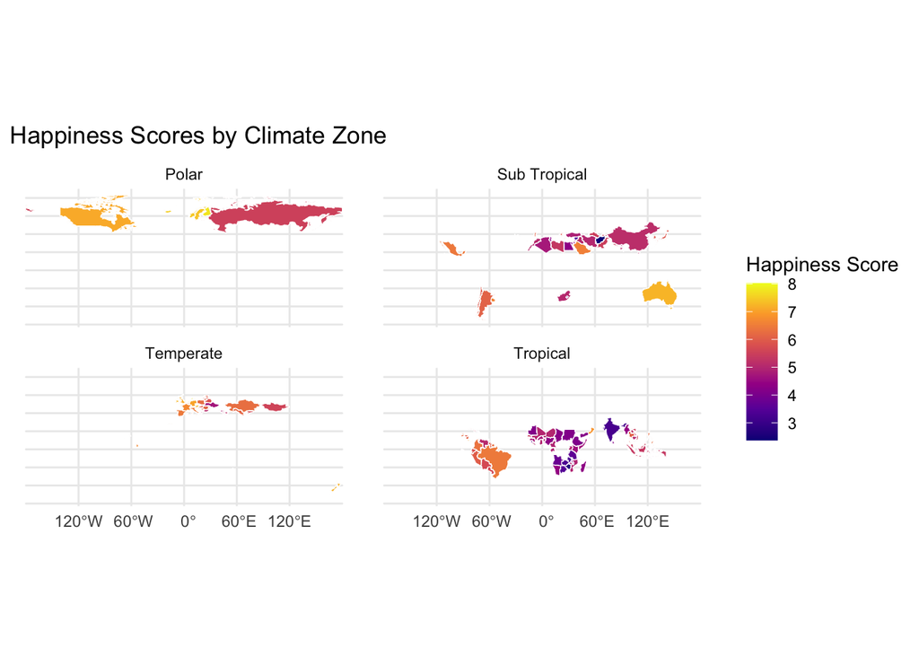

```r
# Visualize happiness scores by climate zone
ggplot(merged_sf) +
  geom_sf(aes(fill = `Life Ladder`), color = "white") +
  facet_wrap(~climate_zone) +
  scale_fill_viridis_c(option = "C") +
  theme_minimal() +
  labs(title = "Happiness Scores by Climate Zone", fill = "Happiness Score")
```

### Moran’s I by Climate Zone

```r
# Subset tropical, sub tropical, temperate, and polar countries
tropical_countries <- merged_sf[merged_sf$climate_zone == "Tropical", ]
subtropical_countries <- merged_sf[merged_sf$climate_zone == "Sub Tropical", ]
temperate_countries <- merged_sf[merged_sf$climate_zone == "Temperate", ]
polar_countries <- merged_sf[merged_sf$climate_zone == "Polar", ]
```

```r
# Create spatial weights for tropical countries
tropical_coords <- st_coordinates(st_centroid(tropical_countries))
tropical_knn <- spdep::knearneigh(tropical_coords, k = 5)
tropical_listw <- spdep::nb2listw(spdep::knn2nb(tropical_knn), style = "W")

# Moran's I for tropical countries
tropical_moran <- spdep::moran.test(tropical_countries$`Life Ladder`, tropical_listw)
print(tropical_moran)
```

```
    Moran I test under randomisation

data:  tropical_countries$`Life Ladder`
weights: tropical_listw

Moran I statistic standard deviate = 39.31, p-value < 2.2e-16
alternative hypothesis: greater
sample estimates:
Moran I statistic       Expectation          Variance
     0.7989590239     -0.0014064698      0.0004145492
```

```r
# Calculate centroids for subtropical countries
subtropical_coords <- st_coordinates(st_centroid(subtropical_countries))

# Create spatial weights using k-nearest neighbors
subtropical_knn <- spdep::knearneigh(subtropical_coords, k = 5)
subtropical_listw <- spdep::nb2listw(spdep::knn2nb(subtropical_knn), style = "W")

# Moran's I for subtropical countries
subtropical_moran <- spdep::moran.test(subtropical_countries$`Life Ladder`, subtropical_listw)
print(subtropical_moran)
```

```
    Moran I test under randomisation

data:  subtropical_countries$`Life Ladder`
weights: subtropical_listw

Moran I statistic standard deviate = 29.766, p-value < 2.2e-16
alternative hypothesis: greater
sample estimates:
Moran I statistic       Expectation          Variance
      0.762913234      -0.002272727       0.000660848
```

```r
# Create spatial weights for temperate countries
temperate_coords <- st_coordinates(st_centroid(temperate_countries))
temperate_knn <- spdep::knearneigh(temperate_coords, k = 5)
temperate_listw <- spdep::nb2listw(spdep::knn2nb(temperate_knn), style = "W")

# Moran's I for temperate countries
temperate_moran <- spdep::moran.test(temperate_countries$`Life Ladder`, temperate_listw)
print(temperate_moran)
```

```
    Moran I test under randomisation

data:  temperate_countries$`Life Ladder`
weights: temperate_listw

Moran I statistic standard deviate = 40.219, p-value < 2.2e-16
alternative hypothesis: greater
sample estimates:
Moran I statistic       Expectation          Variance
     0.9825625838     -0.0020964361      0.0005993889
```

```r
# Create spatial weights for polar countries
polar_coords <- st_coordinates(st_centroid(polar_countries))
polar_knn <- spdep::knearneigh(polar_coords, k = 5)
polar_listw <- spdep::nb2listw(spdep::knn2nb(polar_knn), style = "W")

# Moran's I for Polar countries
polar_moran <- spdep::moran.test(polar_countries$`Life Ladder`, polar_listw)
print(polar_moran)
```

```
    Moran I test under randomisation

data:  polar_countries$`Life Ladder`
weights: polar_listw

Moran I statistic standard deviate = 17.671, p-value < 2.2e-16
alternative hypothesis: greater
sample estimates:
Moran I statistic       Expectation          Variance
      1.060022784      -0.014705882       0.003698951
```

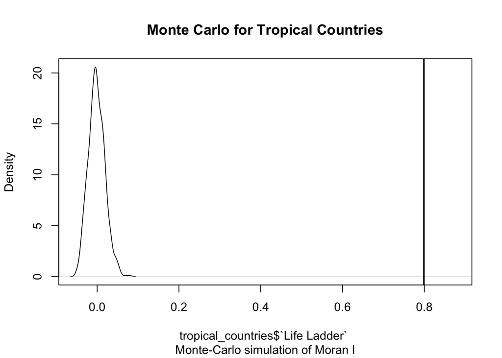

```r
# Monte Carlo simulation for tropical countries
tropical_mc <- spdep::moran.mc(tropical_countries$`Life Ladder`, tropical_listw, nsim = 999)
plot(tropical_mc, main = "Monte Carlo for Tropical Countries")
```

```r
print(tropical_mc)
```

```
    Monte-Carlo simulation of Moran I

data:  tropical_countries$`Life Ladder`
weights: tropical_listw
number of simulations + 1: 1000

statistic = 0.79896, observed rank = 1000, p-value = 0.001
alternative hypothesis: greater
```

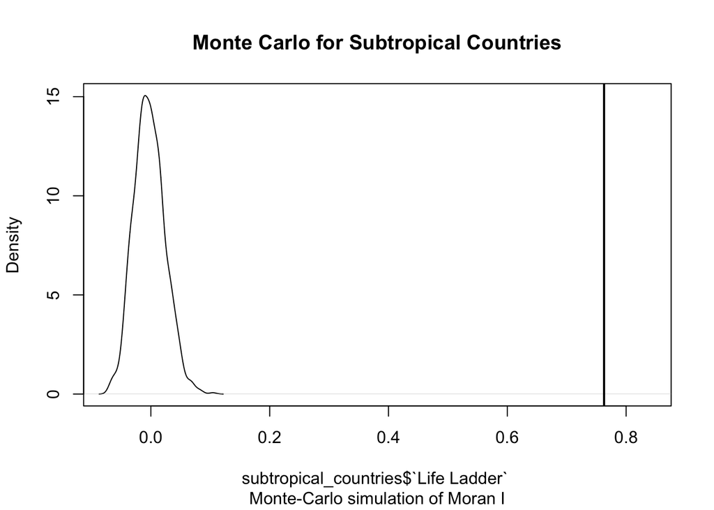

```r
# Monte Carlo simulation for subtropical countries
subtropical_mc <- spdep::moran.mc(subtropical_countries$`Life Ladder`, subtropical_listw, nsim = 999)
plot(subtropical_mc, main = "Monte Carlo for Subtropical Countries")
```

```r
print(subtropical_mc)
```

```
    Monte-Carlo simulation of Moran I

data:  subtropical_countries$`Life Ladder`
weights: subtropical_listw
number of simulations + 1: 1000

statistic = 0.76291, observed rank = 1000, p-value = 0.001
alternative hypothesis: greater
```

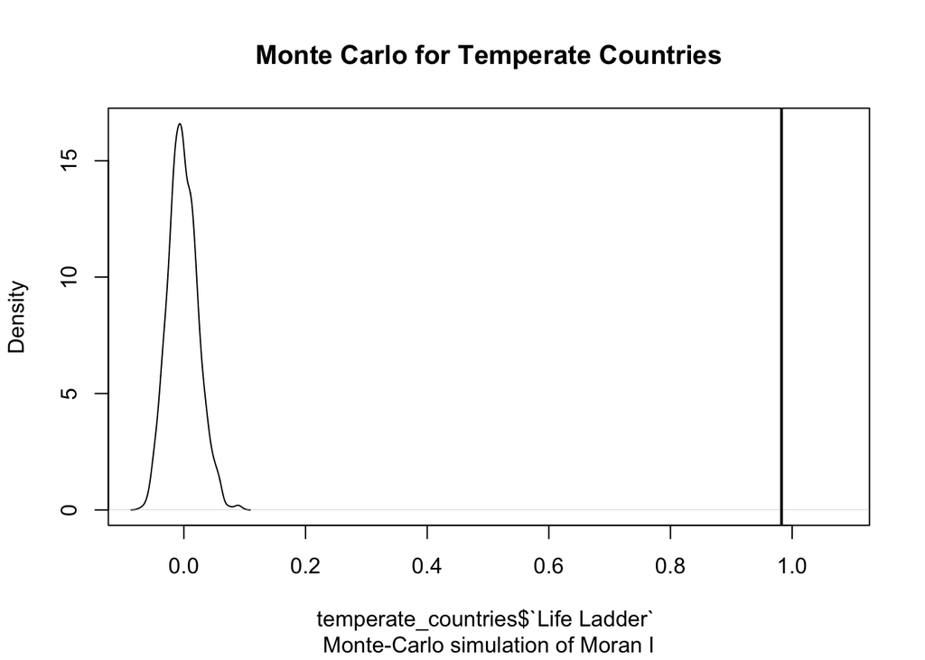

```r
# Monte Carlo simulation for temperate countries
temperate_mc <- spdep::moran.mc(temperate_countries$`Life Ladder`, temperate_listw, nsim = 999)
plot(temperate_mc, main = "Monte Carlo for Temperate Countries")
```

```r
print(temperate_mc)
```

```
    Monte-Carlo simulation of Moran I

data:  temperate_countries$`Life Ladder`
weights: temperate_listw
number of simulations + 1: 1000

statistic = 0.98256, observed rank = 1000, p-value = 0.001
alternative hypothesis: greater
```

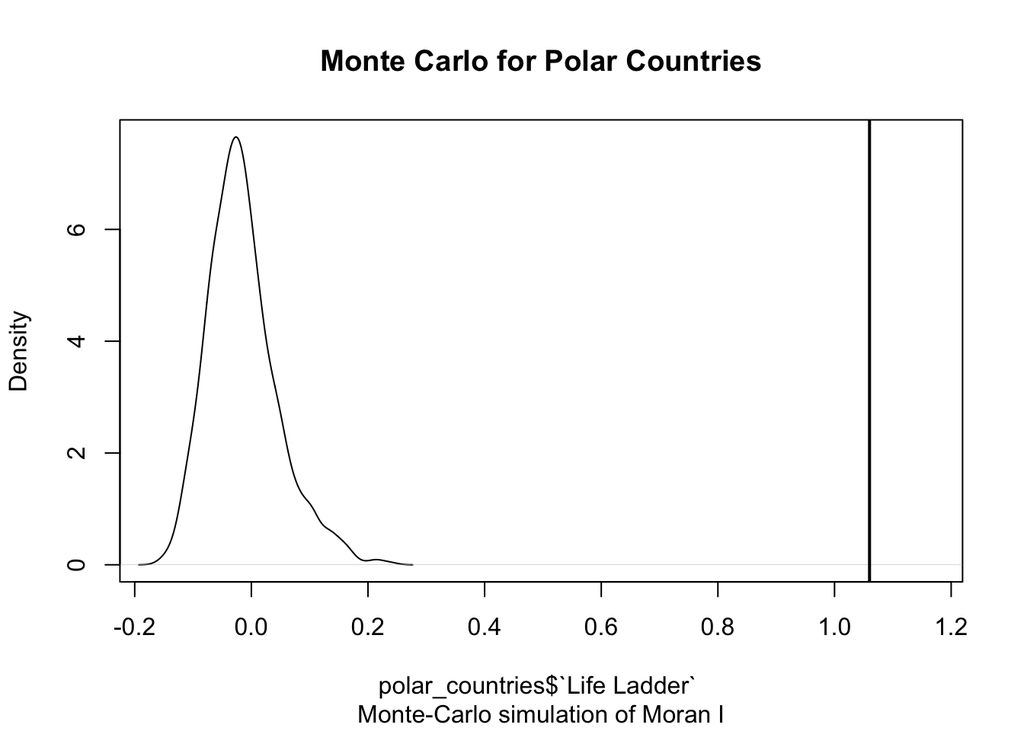

```r
# Monte Carlo simulation for polar countries
polar_mc <- spdep::moran.mc(polar_countries$`Life Ladder`, polar_listw, nsim = 999)
plot(polar_mc, main = "Monte Carlo for Polar Countries")
```

```r
print(polar_mc)
```

```
    Monte-Carlo simulation of Moran I

data:  polar_countries$`Life Ladder`
weights: polar_listw
number of simulations + 1: 1000

statistic = 1.06, observed rank = 1000, p-value = 0.001
alternative hypothesis: greater
```

To look into a closer look at if this result was correct, I checked if there were any outliers for polar regions. It seemed strange to me that people living in extreme conditions had higher happiness scores, and I wanted to check if there were any points in the data that led to a mistinterpretation.

### Polar Outliers

```r
# Count the number of polar countries
num_polar_countries <- nrow(polar_countries)
print(paste("Number of polar countries:", num_polar_countries))
```

```
[1] "Number of polar countries: 69"
```

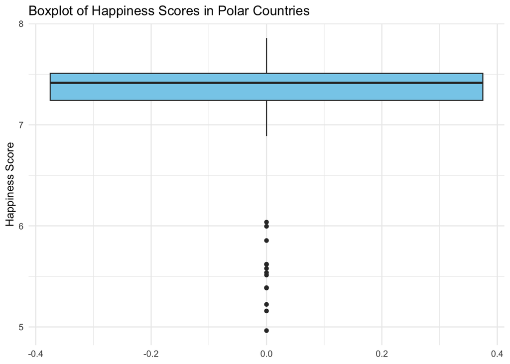

```r
# Boxplot to check for outliers
ggplot(polar_countries, aes(y = `Life Ladder`)) +
  geom_boxplot(fill = "skyblue") +
  theme_minimal() +
  labs(title = "Boxplot of Happiness Scores in Polar Countries", y = "Happiness Score")
```

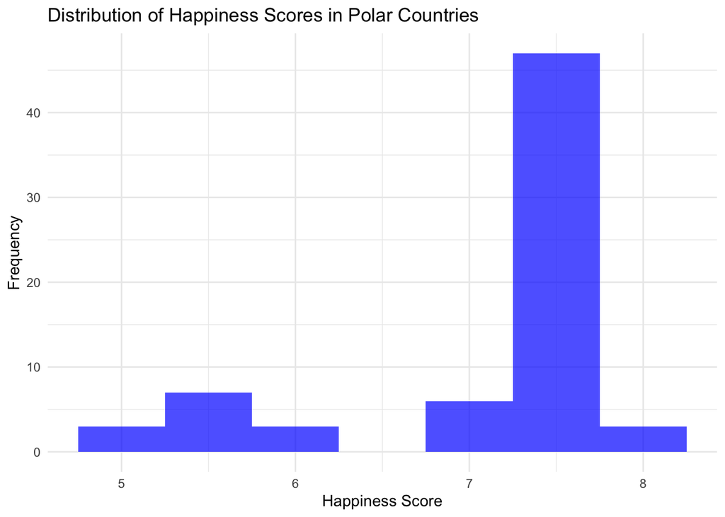

```r
# Histogram for distribution
ggplot(polar_countries, aes(x = `Life Ladder`)) +
  geom_histogram(binwidth = 0.5, fill = "blue", alpha = 0.7) +
  theme_minimal() +
  labs(title = "Distribution of Happiness Scores in Polar Countries", x = "Happiness Score", y = "Frequency")
```

```r
# List polar countries with highest happiness scores
top_polar_countries <- polar_countries %>%
  arrange(desc(`Life Ladder`)) %>%
  select(`name`, `Life Ladder`)
print(top_polar_countries)
```

```
Simple feature collection with 69 features and 2 fields
Geometry type: MULTIPOLYGON
Dimension:     XY
Bounding box:  xmin: -180 ymin: 41.19927 xmax: 180 ymax: 83.11611
Geodetic CRS:  WGS 84
First 10 features:
      name Life Ladder                       geometry
1  Finland    7.858107 MULTIPOLYGON (((24.15547 65...
2  Finland    7.788252 MULTIPOLYGON (((24.15547 65...
3  Finland    7.780348 MULTIPOLYGON (((24.15547 65...
4   Norway    7.678277 MULTIPOLYGON (((20.62217 69...
5  Finland    7.672449 MULTIPOLYGON (((24.15547 65...
6  Finland    7.670627 MULTIPOLYGON (((24.15547 65...
7  Finland    7.659843 MULTIPOLYGON (((24.15547 65...
8   Canada    7.650346 MULTIPOLYGON (((-132.6555 5...
9   Norway    7.632288 MULTIPOLYGON (((20.62217 69...
10  Norway    7.603434 MULTIPOLYGON (((20.62217 69...
```

```r
# Filter out potential outliers (e.g., scores above a certain threshold)
polar_no_outliers <- polar_countries %>%
  filter(`Life Ladder` < quantile(`Life Ladder`, 0.95)) # Adjust threshold if needed

# Recalculate Moran's I for polar countries without outliers
polar_no_outliers_coords <- st_coordinates(st_centroid(polar_no_outliers))
polar_no_outliers_knn <- spdep::knearneigh(polar_no_outliers_coords, k = 5)
polar_no_outliers_listw <- spdep::nb2listw(spdep::knn2nb(polar_no_outliers_knn), style = "W")
polar_no_outliers_moran <- spdep::moran.test(polar_no_outliers$`Life Ladder`, polar_no_outliers_listw)
print(polar_no_outliers_moran)
```

```
    Moran I test under randomisation

data:  polar_no_outliers$`Life Ladder`
weights: polar_no_outliers_listw

Moran I statistic standard deviate = 17.268, p-value < 2.2e-16
alternative hypothesis: greater
sample estimates:
Moran I statistic       Expectation          Variance
      1.078217837      -0.015625000       0.004012719
```

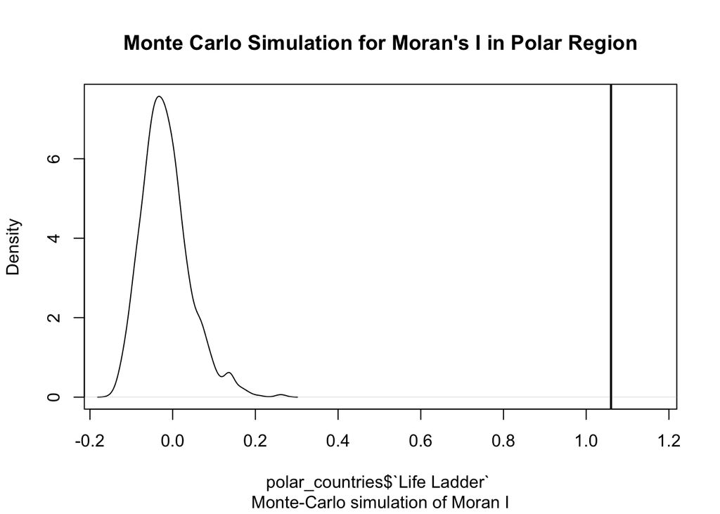

```r
# Monte Carlo simulation for Moran's I in polar region
polar_mc <- spdep::moran.mc(
  polar_countries$`Life Ladder`,
  polar_listw,
  nsim = 999 # Number of simulations
)

# Plot Monte Carlo results
plot(polar_mc, main = "Monte Carlo Simulation for Moran's I in Polar Region")
```

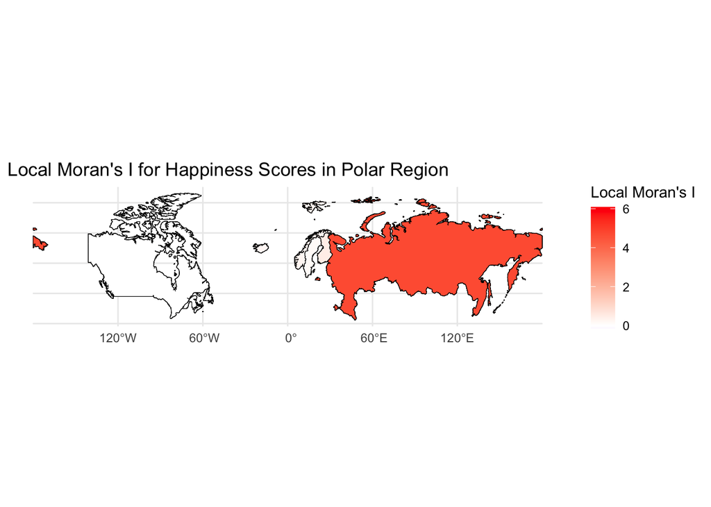

```r
# Calculate Local Moran's I
polar_local_moran <- spdep::localmoran(polar_countries$`Life Ladder`, polar_listw)

# Add Local Moran's I results to the dataset
polar_countries$Ii <- polar_local_moran[, "Ii"]
polar_countries$p_value <- polar_local_moran[, "Pr(z != E(Ii))"]

# Visualize clusters in polar regions
ggplot(polar_countries) +
  geom_sf(aes(fill = Ii), color = "black") +
  scale_fill_gradient2(low = "blue", mid = "white", high = "red", midpoint = 0) +
  theme_minimal() +
  labs(title = "Local Moran's I for Happiness Scores in Polar Region", fill = "Local Moran's I")
```

### Findings

This analysis underscores the influence of geography and climate on happiness. Coastal countries, with access to trade, tourism, and natural resources, tend to have higher happiness scores and stronger clustering. Climate also plays a critical role, with polar and temperate zones benefiting from favorable socioeconomic conditions. The findings highlight how geographic proximity and environmental factors shape well-being, offering insights for policymakers aiming to address disparities.